# AMAP: Assisted Microbial Annotation Pipeline Report

#### F

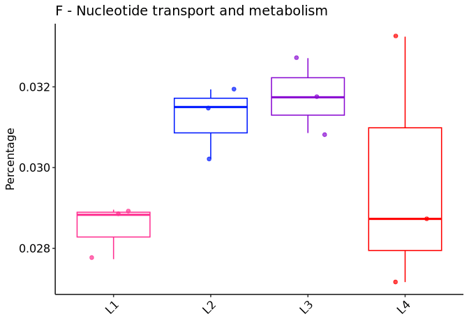

#### G

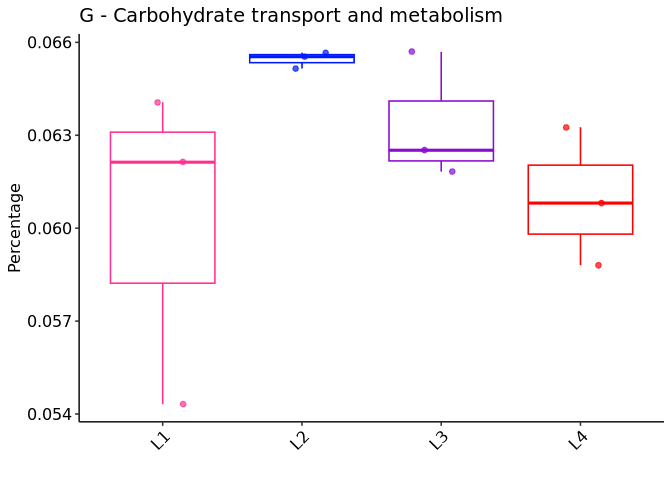

#### H

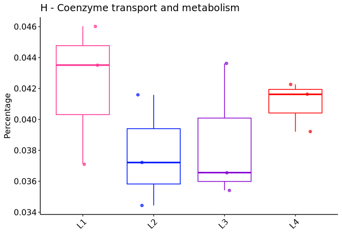

#### I

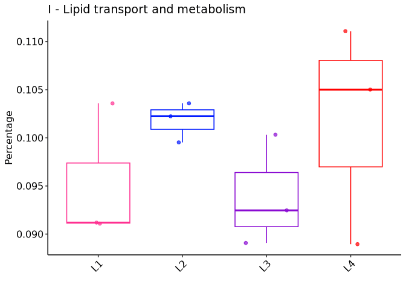

#### J

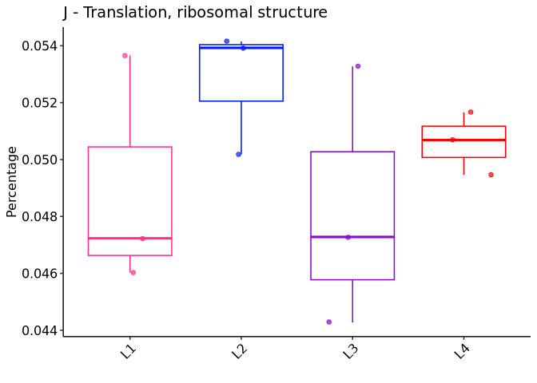

#### K

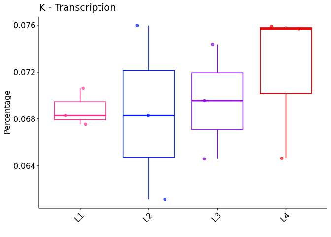

#### L

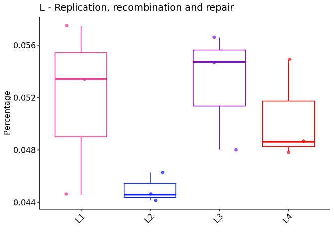

#### M

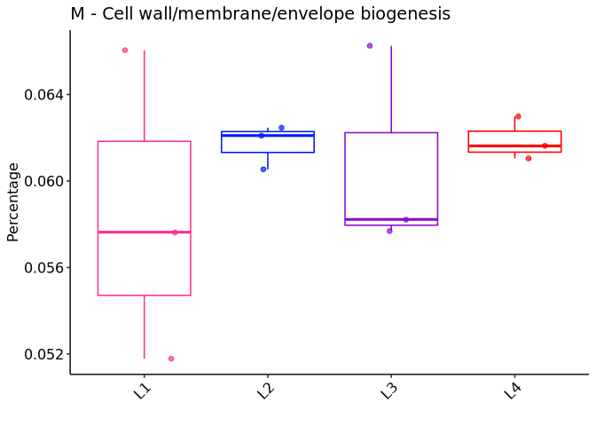

#### N

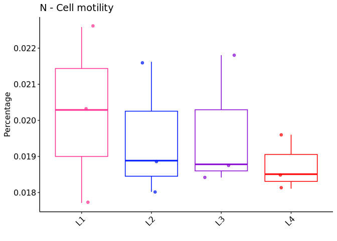

#### O

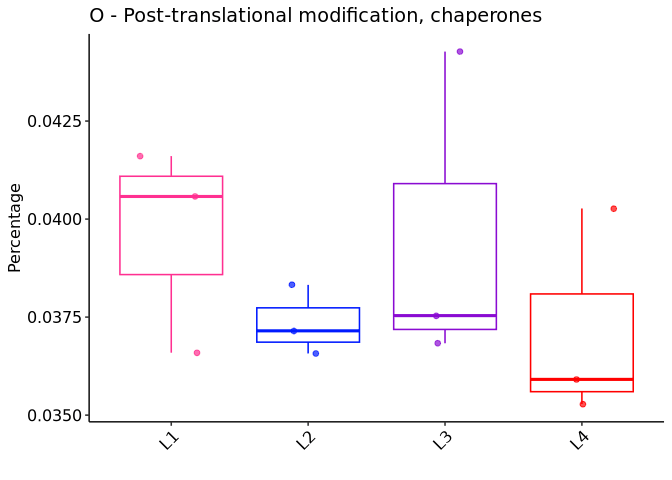

#### P

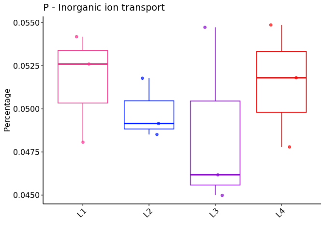

#### Q

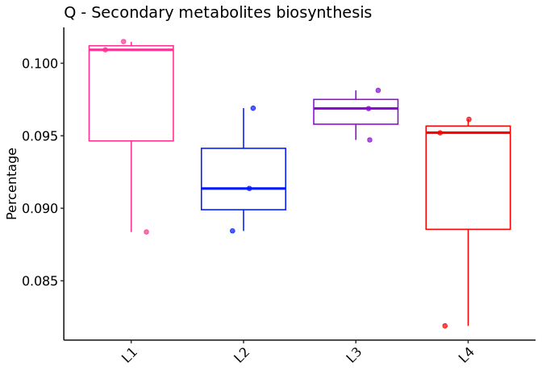